# Testing Vision API on Handwritings

#### Getting a Google API Credential.

First, visit [API console](http://console.cloud.google.com/apis), choose "Credentials" from the dropdown in the left-hand menu. Choose "Create Credentials" and generate an API key for your application. You should probably restrict it by IP address to prevent abuse, but for now, just leave that field blank and delete the API key after trying out this demo.

Then, when you have your key, you will enter it in this first executable cell where prompted.

```python
import getpass

APIKEY = getpass.getpass()
```

```
··········
```

```python
APIKEY
```

```
'AIzaSyDy_BecFckB5vi-dIej_mpRhP9A0qlLOI4'
```

# Vision API testing

```python
# import build
from googleapiclient.discovery import build
# import base64
import base64
# Running Vision API for the combined pictures and get an idea what it looks like for the output.
IMAGE="gs://hw4-image-emory/combined.png"
vservice = build('vision', 'v1', developerKey=APIKEY)
request = vservice.images().annotate(body={
        'requests': [{
                'image': {
                    'source': {
                        'gcs_image_uri': IMAGE
                    }
                },
                'features': [{
                    'type': 'TEXT_DETECTION',
                    'maxResults': 3,
                }]
            }],
        })
responses = request.execute(num_retries=3)
```

```python
#get the text of the output
responses['responses'][0]['fullTextAnnotation']['text']
```

```
'Emery\nTonng\nUn\nEmary Univesty\nEmay Uniesty\nEmny Umay\nEmory University Emory University Emory\nUniversity\nErmory Uniersity\nEmortersty\nUaiversty\nEmery\nUndon\n'
```

## We will examine the individidual handwriting by repeating the same process.

Each person write the same words for three different levels. Individual image is an input for Vision API. Then, we get text that the Vision API transcribed and confidence score for each individual.

```python
IMAGE="gs://hw4-image-emory/emory_control.png"
vservice = build('vision', 'v1', developerKey=APIKEY)
request = vservice.images().annotate(body={
        'requests': [{
                'image': {
                    'source': {
                        'gcs_image_uri': IMAGE
                    }
                },
                'features': [{
                    'type': 'TEXT_DETECTION',
                    'maxResults': 3,
                }]
            }],
        })
control = request.execute(num_retries=3)
#print the text
control['responses'][0]['fullTextAnnotation']['text']
```

```
'Emory University\n'
```

```python
#get confidence value
control['responses'][0]['fullTextAnnotation']
```

[output not shown]

```python
IMAGE="gs://hw4-image-emory/emory_joy.png"
vservice = build('vision', 'v1', developerKey=APIKEY)
request = vservice.images().annotate(body={
        'requests': [{
                'image': {
                    'source': {
                        'gcs_image_uri': IMAGE
                    }
                },
                'features': [{
                    'type': 'TEXT_DETECTION',
                    'maxResults': 3,
                }]
            }],
        })
joy = request.execute(num_retries=3)
#print the text
joy['responses'][0]['fullTextAnnotation']['text']
```

```
'Emory\nUnivorsiay\nBang\n'
```

```python
#get confidence value
joy['responses'][0]['fullTextAnnotation']
```

[output not shown]

```python
IMAGE="gs://hw4-image-emory/emory_daisy.png"
vservice = build('vision', 'v1', developerKey=APIKEY)
request = vservice.images().annotate(body={
        'requests': [{
                'image': {
                    'source': {
                        'gcs_image_uri': IMAGE
                    }
                },
                'features': [{
                    'type': 'TEXT_DETECTION',
                    'maxResults': 3,
                }]
            }],
        })
daisy = request.execute(num_retries=3)
#print the text
daisy['responses'][0]['fullTextAnnotation']['text']
```

```
'Emory Universiby\nE mor\nEmery\nUniversity\nEme\nhvers\n'
```

```python
#get confidence value
daisy['responses'][0]['fullTextAnnotation']
```

[output not shown]

```python
IMAGE="gs://hw4-image-emory/emory_michael.png"
vservice = build('vision', 'v1', developerKey=APIKEY)
request = vservice.images().annotate(body={
        'requests': [{
                'image': {
                    'source': {
                        'gcs_image_uri': IMAGE
                    }
                },
                'features': [{
                    'type': 'TEXT_DETECTION',
                    'maxResults': 3,
                }]
            }],
        })
michael = request.execute(num_retries=3)
#print the text
michael['responses'][0]['fullTextAnnotation']['text']
```

```
'Emory University\nErmory Vniersity\nGamony Uniersty\nUhiersy\n'
```

```python
#get confidence value
michael['responses'][0]['fullTextAnnotation']
```

[output not shown]

```python
IMAGE="gs://hw4-image-emory/emory_shana.png"
vservice = build('vision', 'v1', developerKey=APIKEY)
request = vservice.images().annotate(body={
        'requests': [{
                'image': {
                    'source': {
                        'gcs_image_uri': IMAGE
                    }
                },
                'features': [{
                    'type': 'TEXT_DETECTION',
                    'maxResults': 3,
                }]
            }],
        })
shana = request.execute(num_retries=3)
#print the text
shana['responses'][0]['fullTextAnnotation']['text']
```

```
'Emory Universty\nEimy Uniesty\nEmy luney\n'
```

```python
#get confidence value
shana['responses'][0]['fullTextAnnotation']
```

[output not shown]

```python
IMAGE="gs://hw4-image-emory/emory_aniket.png"
vservice = build('vision', 'v1', developerKey=APIKEY)
request = vservice.images().annotate(body={
        'requests': [{
                'image': {
                    'source': {
                        'gcs_image_uri': IMAGE
                    }
                },
                'features': [{
                    'type': 'TEXT_DETECTION',
                    'maxResults': 3,
                }]
            }],
        })
aniket = request.execute(num_retries=3)
#print the text
aniket['responses'][0]['fullTextAnnotation']['text']
```

```
'Emory\nUniversity\nEmory\nUniversity\nUnidersity\nGhory\nUniversty\n'
```

```python
#get confidence value
aniket['responses'][0]['fullTextAnnotation']
```

[output not shown]

## Results

We recorded data manually and did some statistical analysis. Table 1 showed how we defined accuracy and calculated by counting how many letters Vision API correctly identified. Table 2 recorded the confidence score given by Vision API, and we will see how that compared to our own judgement of the accuracy of the Vision API.

```python
#two data tables are showed below
#importing authorization
from google.colab import auth
auth.authenticate_user()
#importing google spreadsheet
import gspread
from google.auth import default
creds, _ = default()
#giving authorization to application
gc = gspread.authorize(creds)
#Matplotlib (a powerful Python library for data visualization), and Pandas (the number one Python library for data manipulation and analysis)
import pandas as pd
import matplotlib.pyplot as plt
#bringing in spreadsheet data
sp = gc.open_by_url('https://docs.google.com/spreadsheets/d/1EaqsMnl8PcfKMvndttlaY1PsvTf5UH_vwUD2R8l2NCM/edit?usp=sharing')
sheet = sp.worksheet('Sheet1')
data = sheet.get_all_values()
df = pd.DataFrame(data)
df.columns = df.iloc[0]
df = df.iloc[1:]
df
```

| 1 |  | Accuracy | level1: neat | level2: scribble | level3: messy | average |
| --- | --- | --- | --- | --- | --- | --- |
| 2 | control | 0 | 100.00% | n/a | n/a | 100.00% |
| 3 | Joy | 1 | 33.33% | 40.00% | 0.00% | 24.44% |
| 4 | Daisy | 2 | 93.33% | 93.33% | 60.00% | 82.22% |
| 5 | Michael | 3 | 100.00% | 80.00% | 66.67% | 82.22% |
| 6 | Shana | 4 | 93.33% | 73.33% | 40.00% | 68.89% |
| 7 | Aniket | 5 | 100.00% | 100.00% | 73.33% | 91.11% |
| 8 |  |  |  |  |  |  |
| 9 |  |  |  |  |  |  |
| 10 |  | Confidence level |  |  |  |  |
| 11 | control | 1 |  |  |  |  |
| 12 | Joy | 0.26 |  |  |  |  |
| 13 | Daisy | 0.71 |  |  |  |  |
| 14 | Michael | 1 |  |  |  |  |
| 15 | Shana | 1 |  |  |  |  |
| 16 | Aniket | 0.81 |  |  |  |  |

## Visualize with graphs

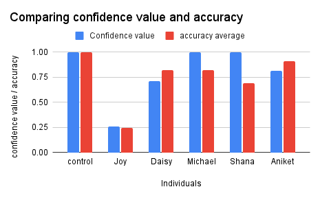

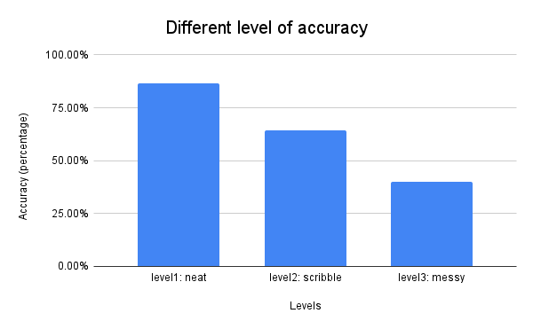

## Conclusion

If anyone is interested in recreating the experiment, you can go to Github repo for more information. It contains the documents and images that we used for this analysis. https://github.com/joyzhou1234/QTM250-example.git